# Practical Mahcine Learning_Project

Lin Ma

March 6, 2019

## Project

**Background**

Using devices such as Jawbone Up, Nike FuelBand, and Fitbit it is now possible to collect a large amount of data about personal activity relatively inexpensively. These type of devices are part of the quantified self movement - a group of enthusiasts who take measurements about themselves regularly to improve their health, to find patterns in their behavior, or because they are tech geeks. One thing that people regularly do is quantify how much of a particular activity they do, but they rarely quantify how well they do it. In this project, your goal will be to use data from accelerometers on the belt, forearm, arm, and dumbell of 6 participants. They were asked to perform barbell lifts correctly and incorrectly in 5 different ways. More information is available from the website here: http://web.archive.org/web/20161224072740/http:/groupware.les.inf.puc-rio.br/har (see the section on the Weight Lifting Exercise Dataset).

## Libraries

```r
library(caret)
library(rpart)
library(rattle)
```

## Loading Data

```r
getwd()
```

```
## [1] "\\\\files/users/lma/Coursera_Practical Machine Learning"
```

```r
download.file("https://d396qusza40orc.cloudfront.net/predmachlearn/pml-training.csv",destfile = "training.csv")
training<-read.csv("training.csv")
summary(training$classe)
```

```
##    A    B    C    D    E
## 5580 3797 3422 3216 3607
```

```r
download.file("https://d396qusza40orc.cloudfront.net/predmachlearn/pml-testing.csv",destfile = "testing.csv")
testing<-read.csv("testing.csv")
summary(testing$user_name)
```

```
##   adelmo carlitos  charles   eurico   jeremy    pedro
##        1        3        1        4        8        3
```

## Clean Data

Take a look at the Data and try to reduce the effect of missing values.

```r
str(training)
```

```
## 'data.frame':    19622 obs. of  160 variables:
##  $ X                       : int  1 2 3 4 5 6 7 8 9 10 ...
##  $ user_name               : Factor w/ 6 levels "adelmo","carlitos",..: 2 2 2 2 2 2 2 2 2 2 ...
##  $ raw_timestamp_part_1    : int  1323084231 1323084231 1323084231 1323084232 1323084232 1323084232 1323084232 1323084232 1323084232 1323084232 ...
##  $ raw_timestamp_part_2    : int  788290 808298 820366 120339 196328 304277 368296 440390 484323 484434 ...
##  $ cvtd_timestamp          : Factor w/ 20 levels "02/12/2011 13:32",..: 9 9 9 9 9 9 9 9 9 9 ...
##  $ new_window              : Factor w/ 2 levels "no","yes": 1 1 1 1 1 1 1 1 1 1 ...
##  $ num_window              : int  11 11 11 12 12 12 12 12 12 12 ...
##  $ roll_belt               : num  1.41 1.41 1.42 1.48 1.48 1.45 1.42 1.42 1.43 1.45 ...
##  $ pitch_belt              : num  8.07 8.07 8.07 8.05 8.07 8.06 8.09 8.13 8.16 8.17 ...
##  $ yaw_belt                : num  -94.4 -94.4 -94.4 -94.4 -94.4 -94.4 -94.4 -94.4 -94.4 -94.4 ...
##  $ total_accel_belt        : int  3 3 3 3 3 3 3 3 3 3 ...
##  $ kurtosis_roll_belt      : Factor w/ 397 levels "","-0.016850",..: 1 1 1 1 1 1 1 1 1 1 ...
##  $ kurtosis_picth_belt     : Factor w/ 317 levels "","-0.021887",..: 1 1 1 1 1 1 1 1 1 1 ...
##  $ kurtosis_yaw_belt       : Factor w/ 2 levels "","#DIV/0!": 1 1 1 1 1 1 1 1 1 1 ...
```

[output cut: 86 more lines]

```r
dim(training)
```

```
## [1] 19622   160
```

```r
c_training<-training[,-which(colSums(is.na(training)|training=="")>0.9*dim(training)[1])]
c_training<-c_training[,-c(1:7)]


c_testing<-testing[,-which(colSums(testing==""|is.na(testing))>0.9&dim(testing)[1])]
c_testing<-c_testing[,-c(1:7)]
```

We have cleaned up all the columns with over 90% NA values.

## create train and test dataset inside Training Dataset

```r
set.seed(1314)
training_index<-createDataPartition(c_training$classe,p=0.75,list=FALSE)
new_training<-c_training[training_index,]
new_testing<-c_training[-training_index,]
```

## Classification Trees

First, letr’s try using the classification tree.

```r
set.seed(520)
traincontrol<-trainControl(method="cv",number = 5)
model_rpart<-train(classe~.,data = new_training,method='rpart',trControl=traincontrol)
```

Let’s see the plot of the final model.

[figure not shown]

```r
prediction<-predict(model_rpart,newdata=new_testing)
confusionMatrix(prediction,new_testing$classe)
```

```
## Confusion Matrix and Statistics
##
##           Reference
## Prediction    A    B    C    D    E
##          A 1272  390  387  365  126
##          B   17  327   25  147  116
##          C  101  232  443  292  252
##          D    0    0    0    0    0
##          E    5    0    0    0  407
##
## Overall Statistics
##
##                Accuracy : 0.4994
##                  95% CI : (0.4853, 0.5135)
##     No Information Rate : 0.2845
##     P-Value [Acc > NIR] : < 2.2e-16
##
##                   Kappa : 0.3459
##  Mcnemar's Test P-Value : NA
##
## Statistics by Class:
##
##                      Class: A Class: B Class: C Class: D Class: E
## Sensitivity            0.9118  0.34457  0.51813   0.0000  0.45172
## Specificity            0.6386  0.92288  0.78340   1.0000  0.99875
## Pos Pred Value         0.5008  0.51741  0.33561      NaN  0.98786
## Neg Pred Value         0.9480  0.85440  0.88504   0.8361  0.89003
## Prevalence             0.2845  0.19352  0.17435   0.1639  0.18373
## Detection Rate         0.2594  0.06668  0.09033   0.0000  0.08299
## Detection Prevalence   0.5179  0.12887  0.26917   0.0000  0.08401
## Balanced Accuracy      0.7752  0.63373  0.65077   0.5000  0.72524
```

The accuracy we get is even under 50%, which means our variables in this model couldn’t explain the dependent variable very well.

## Train with Random Forests

```r
set.seed(6688)
model_rf<-train(classe~.,data=new_training,method="rf",trControl=traincontrol)
prediction_rf<-predict(model_rf,newdata=new_testing)
confusionMatrix(prediction_rf,new_testing$classe)
```

```
## Confusion Matrix and Statistics
##
##           Reference
## Prediction    A    B    C    D    E
##          A 1395    4    0    0    0
##          B    0  943    3    0    0
##          C    0    2  852   17    0
##          D    0    0    0  786    4
##          E    0    0    0    1  897
##
## Overall Statistics
##
##                Accuracy : 0.9937
##                  95% CI : (0.991, 0.9957)
##     No Information Rate : 0.2845
##     P-Value [Acc > NIR] : < 2.2e-16
##
##                   Kappa : 0.992
##  Mcnemar's Test P-Value : NA
##
## Statistics by Class:
##
##                      Class: A Class: B Class: C Class: D Class: E
## Sensitivity            1.0000   0.9937   0.9965   0.9776   0.9956
## Specificity            0.9989   0.9992   0.9953   0.9990   0.9998
## Pos Pred Value         0.9971   0.9968   0.9782   0.9949   0.9989
## Neg Pred Value         1.0000   0.9985   0.9993   0.9956   0.9990
## Prevalence             0.2845   0.1935   0.1743   0.1639   0.1837
## Detection Rate         0.2845   0.1923   0.1737   0.1603   0.1829
## Detection Prevalence   0.2853   0.1929   0.1776   0.1611   0.1831
## Balanced Accuracy      0.9994   0.9965   0.9959   0.9883   0.9977
```

Take a look at the relationship between random selected predictors and the accuracy.

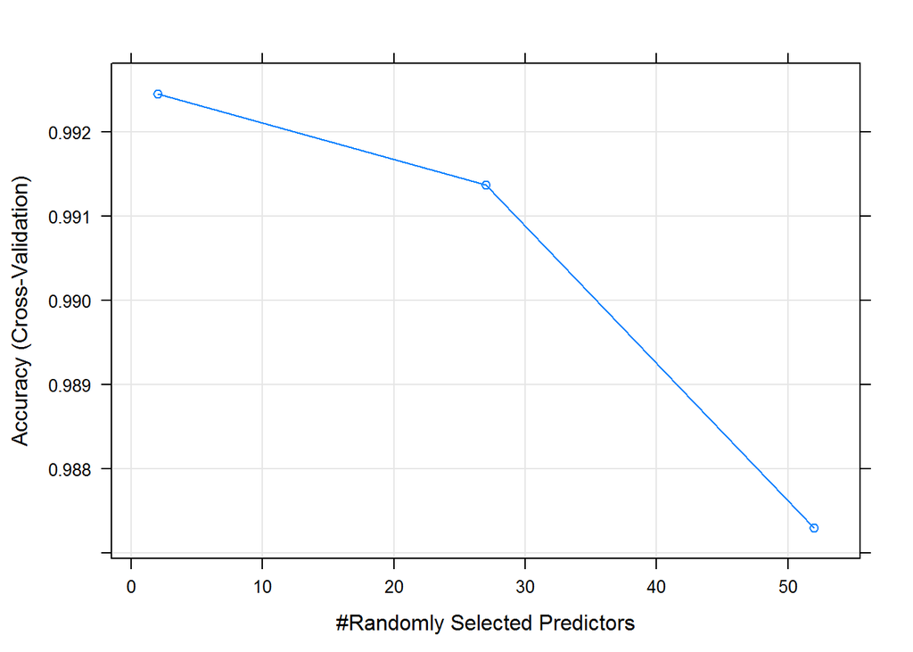

```r
plot(model_rf)
```

Rank the Importance of the features

```r
varImp(model_rf)
```

```
## rf variable importance
##
##   only 20 most important variables shown (out of 52)
##
##                   Overall
## roll_belt          100.00
## yaw_belt            82.56
## magnet_dumbbell_z   70.86
## pitch_belt          63.01
## magnet_dumbbell_y   61.97
## pitch_forearm       61.88
## roll_forearm        52.30
## magnet_dumbbell_x   51.68
## accel_dumbbell_y    44.97
## accel_belt_z        44.26
## magnet_belt_y       43.87
## magnet_belt_z       43.37
## roll_dumbbell       40.48
## accel_dumbbell_z    37.09
## roll_arm            34.34
## accel_forearm_x     33.37
## gyros_belt_z        29.82
## accel_arm_x         28.87
## gyros_dumbbell_y    28.50
## accel_dumbbell_x    28.39
```

We Could see ‘roll_belt’ plays a pivotal role in this model. If I can do another analysis, I will dig more in to the relationship between roll_belt and classe.

## Train with Gradient Boosting Machine

```r
set.seed(12580)
model_gbm<-train(classe~.,data=new_training,method="gbm",verbose=FALSE,trControl=traincontrol)
prediction_gbm<-predict(model_gbm,newdata=new_testing)
confusionMatrix(prediction_gbm,new_testing$classe)
```

```
## Confusion Matrix and Statistics
##
##           Reference
## Prediction    A    B    C    D    E
##          A 1368   36    2    1    2
##          B   17  889   30    4    7
##          C    5   23  813   28    8
##          D    3    1    9  763    9
##          E    2    0    1    8  875
##
## Overall Statistics
##
##                Accuracy : 0.96
##                  95% CI : (0.9542, 0.9653)
##     No Information Rate : 0.2845
##     P-Value [Acc > NIR] : < 2.2e-16
##
##                   Kappa : 0.9494
##  Mcnemar's Test P-Value : 0.0001789
##
## Statistics by Class:
##
##                      Class: A Class: B Class: C Class: D Class: E
## Sensitivity            0.9806   0.9368   0.9509   0.9490   0.9711
## Specificity            0.9883   0.9853   0.9842   0.9946   0.9973
## Pos Pred Value         0.9709   0.9388   0.9270   0.9720   0.9876
## Neg Pred Value         0.9923   0.9848   0.9896   0.9900   0.9935
## Prevalence             0.2845   0.1935   0.1743   0.1639   0.1837
## Detection Rate         0.2790   0.1813   0.1658   0.1556   0.1784
## Detection Prevalence   0.2873   0.1931   0.1788   0.1601   0.1807
## Balanced Accuracy      0.9845   0.9611   0.9675   0.9718   0.9842
```

The Accuracy of GBM model is 96% which is also impressive.

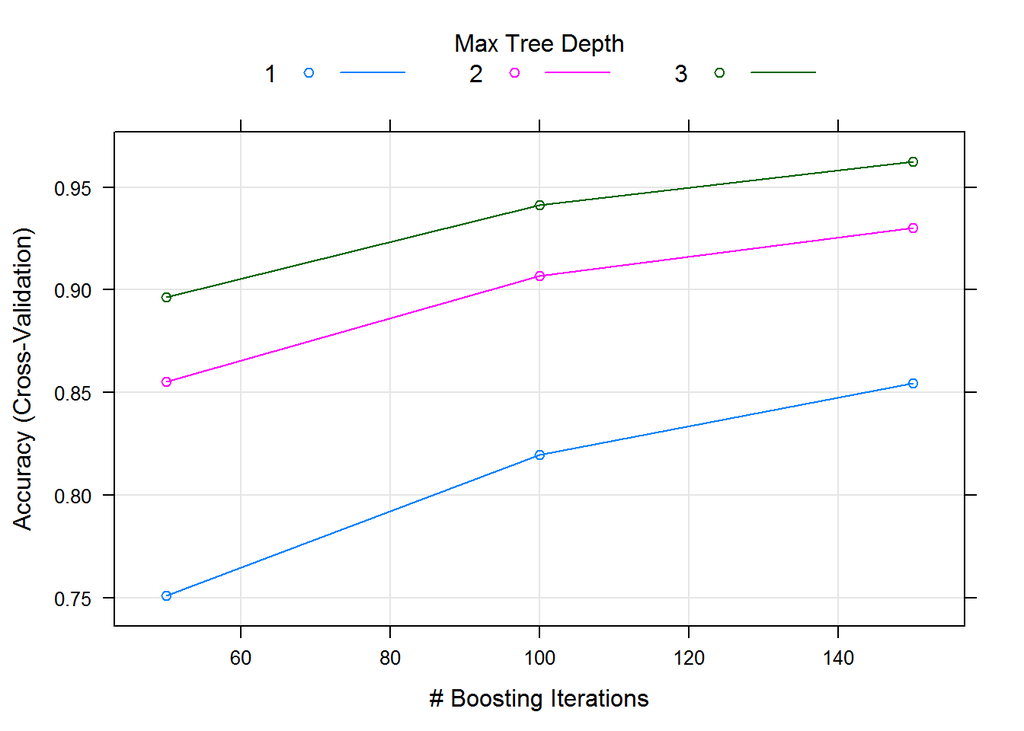

From the plot, we can clearly see the Accuracy boosting by each iteration.

## Conclusion

After comparison, we decided to use Random Forest to predict the final values.

```r
prediction_final<-predict(model_rf,newdata=c_testing)
prediction_final
```

```
##  [1] B A B A A E D B A A B C B A E E A B B B
## Levels: A B C D E
```